# Forest biomass mapping based on mean top-of-canopy height

The study aims to create a forest biomass map in Eberswalde, Germany based on mean top-of-canopy height (TCH) raster model. In the first step, a point cloud of Traunstein forest and inventory data were used to derive TCH-to-biomass relationship in Traunstein forest. We assume that the TCH-to-biomass relationship in Traunstein forest is similar with that of Eberswalde forest. With this assumption, in the second step, using the Traunstein TCH-to-biomass relationship to predict or map biomass in Eberswalde.

Viet Nguyen

Faculty of Forest and Environment  
Eberswalde University for Sustainable Development  
Duc.Nguyen@hnee.de

September, 2022

> 🛈 Information: This project was hosted at [GitHub](https://github.com/VietDucNg/biomass-from_TCH).

> 💾 Data: [Eberswalde forest point cloud](https://github.com/VietDucNg/biomass-from_TCH/blob/main/data/Eberswalde/419500_5853000.laz)  
> [Traunstein forest point cloud](https://github.com/VietDucNg/biomass-from_TCH/blob/main/data/Traunstein/Subplot_PointCloud_Transformed.rds)  
> [Traunstein forest inventory](https://github.com/VietDucNg/biomass-from_TCH/blob/main/data/Traunstein/Subplot_Inventory.rds)

# Prepare workspace

> 📝 note: To ensure reproduce R environment, this project provide **renv** and **R-4.02** folder.

```r
# check working directory
getwd()

# Check path which R loads the packages from
.libPaths()
```

```r
# change path to renv folder which R should loads packages from
getwd()
.libPaths(new=paste0(getwd(), "/renv/library/R-4.0/x86_64-w64-mingw32"))
.libPaths()

# load packages
library(slidaRtools)
```

```r
library(data.table)
library(raster)
library(rgl)
library(lidR)

## prepare parallel processing with lidR
# get how many CPU threads lidR using
get_lidr_threads()
# set how many threads lidR should use
set_lidr_threads(0.8) # recommended to use maximum 80% of total threads
# check how many CPU threads lidR using again
get_lidr_threads()
```

# 1. Derive TCH-to-biomass relationship in Traunstein forest

|  | X | Y | Z | Intensity | ReturnNumber | NumberOfReturns | ScanDirectionFlag | EdgeofFlightLine | Classification | ScanAngleRank | UserData | PointSourceID | R | G | B | PlotNo |
| --- | --- | --- | --- | --- | --- | --- | --- | --- | --- | --- | --- | --- | --- | --- | --- | --- |
| 2200 | 506.05 | 0.59 | 0.11 | 22 | 5 | 5 | 0 | 0 | 1 | 31 | 1 | 5 | 0 | 0 | 0 | 6 |
| 2203 | 506.12 | 0.98 | 0.08 | 12 | 3 | 3 | 0 | 0 | 1 | 31 | 1 | 5 | 0 | 0 | 0 | 6 |
| 2283 | 505.58 | 0.04 | 0.00 | 9 | 4 | 4 | 0 | 0 | 2 | 31 | 0 | 5 | 0 | 0 | 0 | 6 |
| 2778 | 503.88 | 0.29 | 0.53 | 25 | 3 | 3 | 0 | 0 | 1 | 31 | 5 | 5 | 0 | 0 | 0 | 6 |
| 2871 | 503.47 | 0.15 | 0.36 | 9 | 4 | 4 | 0 | 0 | 1 | 31 | 4 | 5 | 0 | 0 | 0 | 6 |
| 6543 | 449.15 | 0.17 | 0.19 | 8 | 5 | 5 | 0 | 0 | 1 | 30 | 2 | 5 | 0 | 0 | 0 | 5 |

```r
# see point cloud in 3D
display.point.cloud(pc.df, size=2)
```

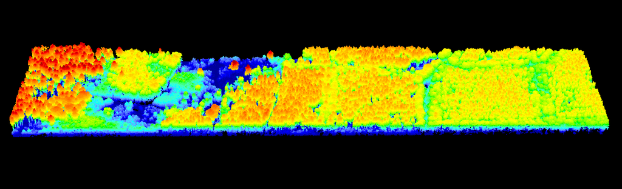

```r
# derive canopy height model (CHM) from point cloud
chm.ras <- raster.from.point.cloud(pc.df, res=1, func="max")
```

```r
chm.ras
```

```
class      : RasterLayer
dimensions : 200, 900, 180000  (nrow, ncol, ncell)
resolution : 1, 1  (x, y)
extent     : 0, 900, 0, 200  (xmin, xmax, ymin, ymax)
crs        : NA
source     : memory
names      : layer
values     : -0.01, 40.49  (min, max)
```

```r
# Convert (melt) the CHM from a raster into to a XYZ-table
chm.df <- ras2xyzdf(chm.ras)
```

|  | X | Y | Z |
| --- | --- | --- | --- |
| 1 | 1 | 1 | 7.18 |
| 2 | 2 | 1 | 7.32 |
| 3 | 3 | 1 | 28.61 |
| 4 | 4 | 1 | 0.61 |
| 5 | 5 | 1 | 0.76 |
| 6 | 6 | 1 | 0.86 |

```r
# Assign spatial grid indices (to each CHM pixel) with a plot resolution of 50 m
chm.df$SpatID <- calc.spatial.index(xcor=chm.df$X, ycor=chm.df$Y, res=50)
```

|  | X | Y | Z | SpatID |
| --- | --- | --- | --- | --- |
| 179995 | 895 | 200 | 16.64 | 72 |
| 179996 | 896 | 200 | 3.87 | 72 |
| 179997 | 897 | 200 | 3.68 | 72 |
| 179998 | 898 | 200 | 4.42 | 72 |
| 179999 | 899 | 200 | 4.22 | 72 |
| 180000 | 900 | 200 | 1.55 | 72 |

```r
display.point.cloud(chm.df, col.var="SpatID", col.lim=c(1, 72))
```

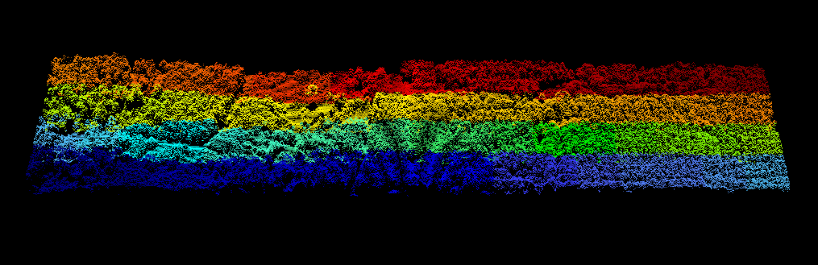

| SpatID | TCH |
| --- | --- |
| 1 | 19.170990 |
| 2 | 21.990508 |
| 3 | 15.665799 |
| 4 | 7.971601 |
| 5 | 12.225519 |
| 6 | 16.992462 |

```r
# Load Traunstein inventory data
inv.df <- readRDS("Data\\Traunstein\\Subplot_Inventory.rds")
```

```r
# take a look at the inventory data
head(inv.df)
```

```r
# Assign spatial grid indices (to each tree) with a plot resolution of 50 m
inv.df$SpatID <- calc.spatial.index(xcor=inv.df$X, ycor=inv.df$Y, res=50)
```

|  | TreeID | X | Y | Species | DBH | H | CL | CD | WD | AGB | SpatID |
| --- | --- | --- | --- | --- | --- | --- | --- | --- | --- | --- | --- |
| 1 | 596 | 885.8985 | 199.7745 | Fichte | 0.385 | 29.99 | 13.580 | 6.33 | 0.436 | 0.871121 | 72 |
| 2 | 597 | 881.0740 | 197.4405 | Fichte | 0.265 | 23.88 | 10.436 | 4.75 | 0.436 | 0.376346 | 72 |
| 3 | 598 | 883.6381 | 197.7127 | Fichte | 0.168 | 17.34 | 7.304 | 3.34 | 0.436 | 0.110720 | 72 |
| 4 | 599 | 889.9917 | 198.0024 | Fichte | 0.405 | 30.85 | 14.040 | 6.58 | 0.436 | 0.968133 | 72 |
| 5 | 600 | 878.3223 | 195.3451 | Fichte | 0.259 | 23.52 | 10.260 | 4.66 | 0.436 | 0.356031 | 72 |
| 6 | 601 | 879.2633 | 195.2771 | Fichte | 0.157 | 16.47 | 6.908 | 3.17 | 0.436 | 0.089929 | 72 |

| SpatID | AGB |
| --- | --- |
| 1 | 67.26282 |
| 2 | 97.69394 |
| 3 | 39.22270 |
| 4 | 12.84868 |
| 5 | 48.86794 |
| 6 | 55.60699 |

[figure not shown]

```r
curve(a*x^b, add=T, col="red")
```

# 2. Preprocessing Eberswalde forest point cloud

| X | Y | Z | gpstime | Intensity | ReturnNumber | NumberOfReturns | ScanDirectionFlag | EdgeOfFlightline | Classification | Synthetic_flag | Keypoint_flag | Withheld_flag | ScanAngleRank | UserData | PointSourceID |
| --- | --- | --- | --- | --- | --- | --- | --- | --- | --- | --- | --- | --- | --- | --- | --- |
| 419500 | 5853498 | 29.02 | 308689.4 | 31 | 6 | 6 | 0 | 0 | 1 | FALSE | FALSE | FALSE | 92 | 0 | 1041 |
| 419500 | 5853474 | 24.61 | 308689.7 | 642 | 1 | 1 | 0 | 0 | 1 | FALSE | FALSE | FALSE | 94 | 0 | 1041 |
| 419500 | 5853465 | 50.75 | 308689.8 | 53 | 4 | 5 | 0 | 0 | 1 | FALSE | FALSE | FALSE | 95 | 0 | 1041 |
| 419500 | 5853445 | 33.37 | 308690.0 | 14 | 4 | 5 | 0 | 0 | 1 | FALSE | FALSE | FALSE | 98 | 0 | 1041 |
| 419500 | 5853438 | 29.43 | 308690.1 | 10 | 2 | 3 | 0 | 0 | 1 | FALSE | FALSE | FALSE | 99 | 0 | 1041 |
| 419500 | 5853424 | 28.76 | 308690.2 | 143 | 5 | 5 | 0 | 0 | 1 | FALSE | FALSE | FALSE | 101 | 0 | 1041 |

```r
# Plot the point cloud
plot(ew.las)
```

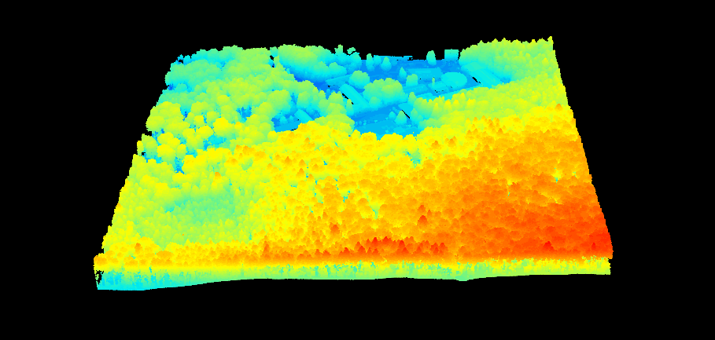

The study area in Eberswalde includes ground and building area which are not our interest for biomass mapping. In the next steps, we classify the point cloud and set height values of points classified as ground or building to 0.

```r
table(ew.las@data$planar)
```

```
  FALSE    TRUE
5854545  202076
```

```r
# plot Eberswalde point cloud with building coloring
plot(ew.las, color = "Building")
```

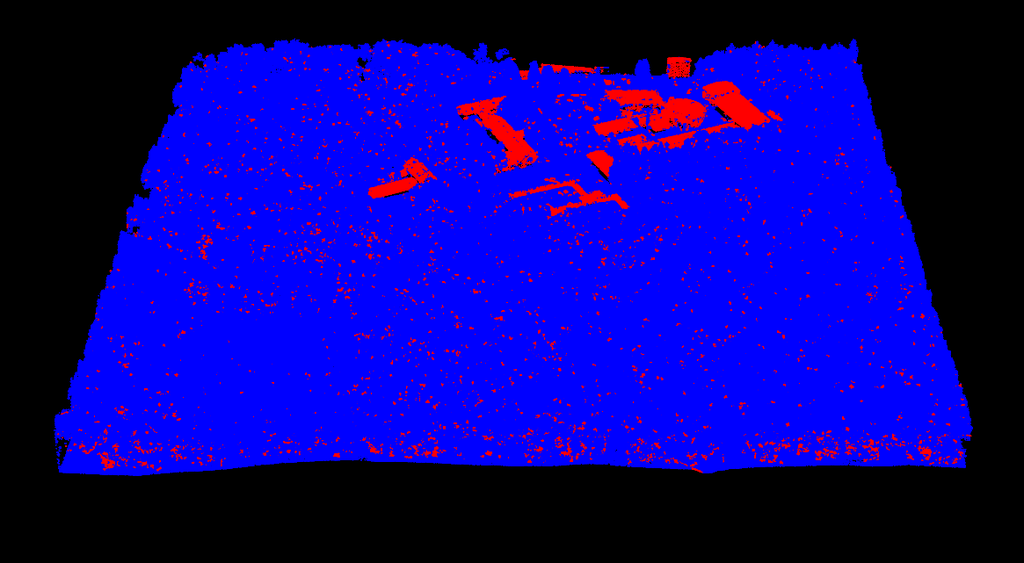

```r
# plot Eberswalde point cloud with planar coloring
plot(ew.las, color = "planar")
```

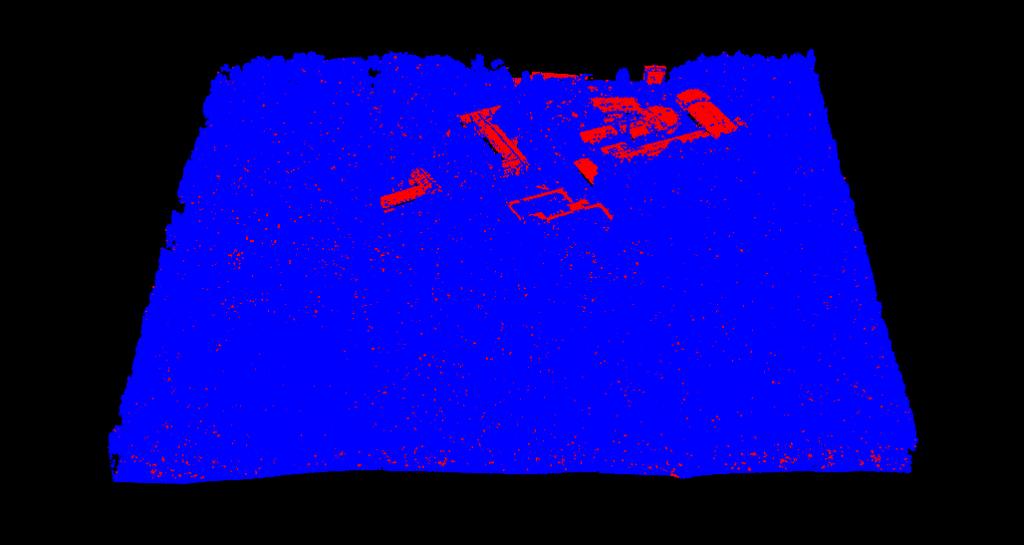

```r
# Terrain normalize the point cloud
norm.ew.las <- lidR::normalize_height(ew.las, knnidw())
```

[output not shown]

```r
# plot terrain normalized point cloud
plot(norm.ew.las)
```

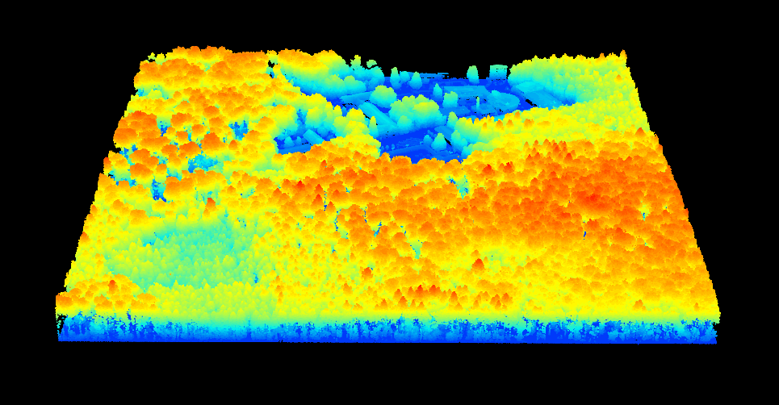

```r
# Check if the buildings have disappeared
display.point.cloud(norm.ew.df)
```

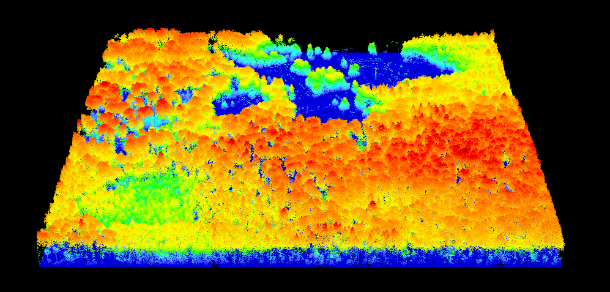

```r
# create CHM for Eberswalde forest
ew.chm.ras <- raster.from.point.cloud(norm.ew.dt, res=1, func="max")
```

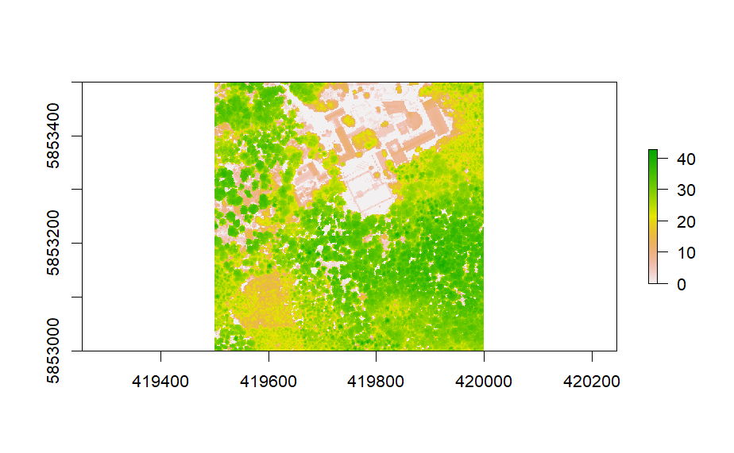

# 3. Using the Traunstein TCH-to-biomass relationship to predict or map biomass in Eberswalde

There are 2 approaches:

## 3.1. Raster aggregate: the fast solution

This is a very fast solution, because TCH is a raster metric, which can be calculated directly using raster aggregation. For a more general solution using XYZ-table conversion and spatial indexing (second approach). The more general solution can be applied to raster metrics and point cloud metrics (e.g., MCH).

```r
# Assign CRS to raster
crs(agb.50m.ras) <- CRS("+init=epsg:32633")
```

## 3.2. Spatial indexing: the versatile preference

This approach does not use raster aggregation. Instead conversion to XYZ-table and spatial indexing is used. This solution is not restricted to raster metrics, i.e., it also works for making maps from point cloud metrics.

```r
# Convert the CHM to a XYZ-table
ew.chm.df <- ras2xyzdf(ew.chm.ras)
```

|  | X | Y | Z |
| --- | --- | --- | --- |
| 1 | 419501 | 5853001 | 29.154 |
| 2 | 419502 | 5853001 | 21.467 |
| 3 | 419503 | 5853001 | 17.283 |
| 4 | 419504 | 5853001 | 32.203 |
| 5 | 419505 | 5853001 | 32.245 |
| 6 | 419506 | 5853001 | 31.217 |

```r
# Calculate spatial ID for the CHM data.frame (i.e. each raster pixel)
ew.chm.df$PlotID <- calc.spatial.index(xcor=ew.chm.df$X, ycor=ew.chm.df$Y, res=50)
```

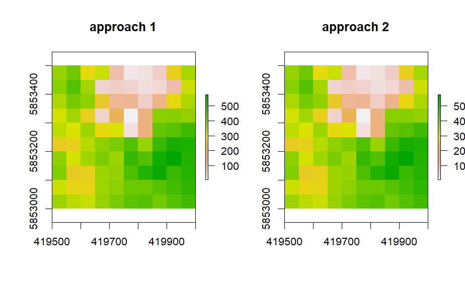